# Axes

Author

James

Published

November 25, 2024

## 1. Box plot

- Draw boxplot using `PlantGrowth` dataset.
- x axis represents `group`, y axis represents `weight`.
- Use `geom_boxplot()` function to draw boxplot.
- Use `labs()` function to add title, axis labels, and caption.
- Use `theme()` function to center the title.

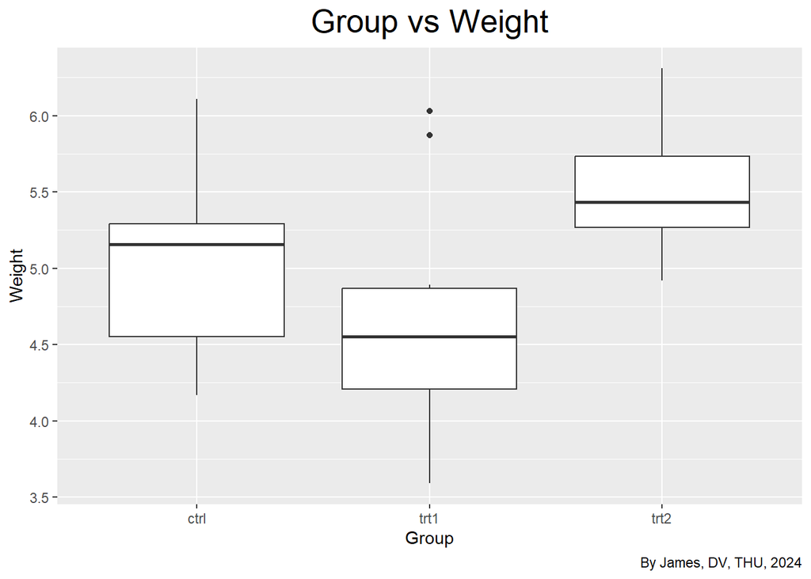

```r
library(ggplot2)

ggplot(PlantGrowth, aes(x = group, y = weight)) +
  geom_boxplot() +
  labs(title = 'Group vs Weight',
       x = 'Group',
       y = 'Weight',
       caption = 'By James, DV, THU, 2024') +
  theme(plot.title = element_text(hjust = 0.5, size=20))
```

## 2. Swap X and Y axes

- Use `coord_flip()` function to swap x and y axes.

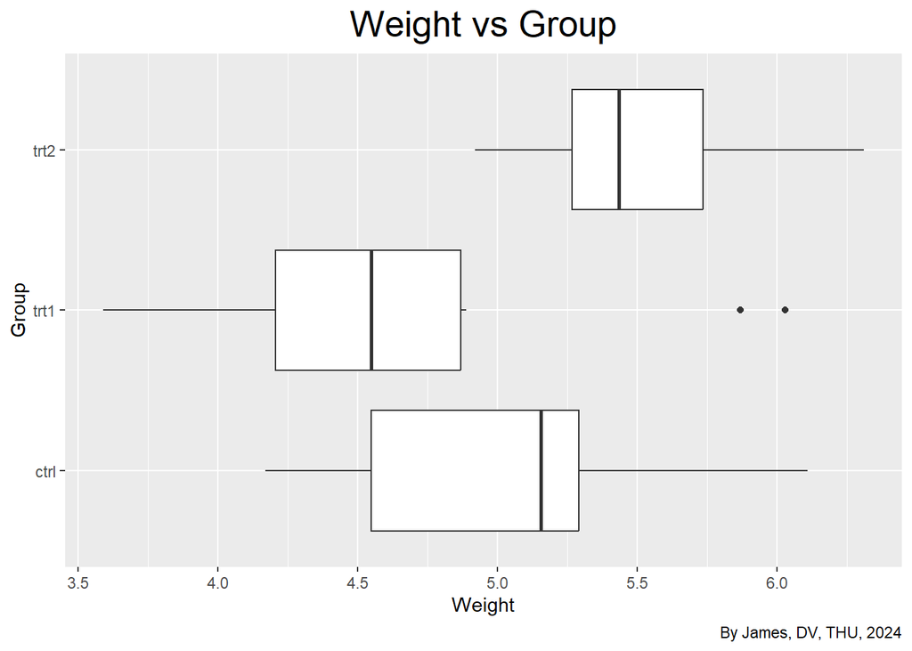

```r
ggplot(PlantGrowth, aes(x = group, y = weight)) +
  geom_boxplot() +
  coord_flip() +
  labs(title = 'Weight vs Group',
       x = 'Group',
       y = 'Weight',
       caption = 'By James, DV, THU, 2024') +
  theme(plot.title = element_text(hjust = 0.5, size=20))
```

## 3. Arrange two plots side by side

- Install `gridExtra` library.
- Prepare two plots: `p1`, `p2`.
- Use `grid.arrange()` function to arrange plots and add title.

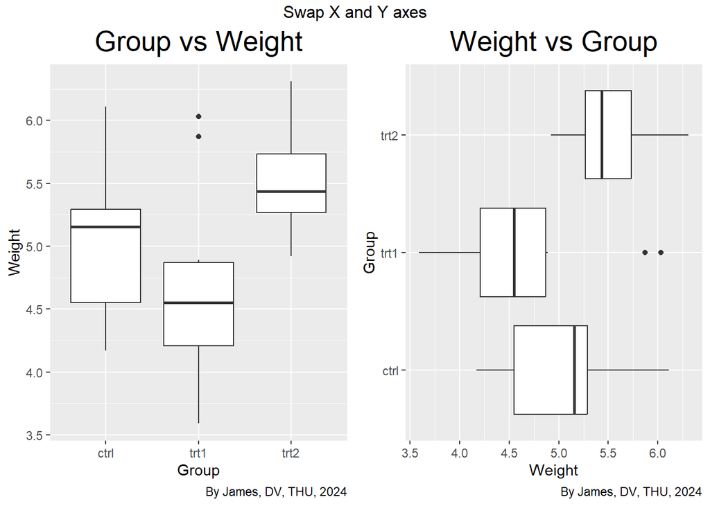

```r
library(gridExtra)

p1 <- ggplot(PlantGrowth, aes(x = group, y = weight)) +
  geom_boxplot() +
  labs(title = 'Group vs Weight',
       x = 'Group',
       y = 'Weight',
       caption = 'By James, DV, THU, 2024') +
  theme(plot.title = element_text(hjust = 0.5, size=20))

p2 <- ggplot(PlantGrowth, aes(x = group, y = weight)) +
  geom_boxplot() +
  coord_flip() +
  labs(title = 'Weight vs Group',
       x = 'Group',
       y = 'Weight',
       caption = 'By James, DV, THU, 2024') +
  theme(plot.title = element_text(hjust = 0.5, size=20))

# Add title
grid.arrange(p1, p2, ncol = 2,
             top = 'Swap X and Y axes')
```

## 4. Setting the Range of a Continuous Axis

- `ylim()`: Sets the limits of the y-axis.

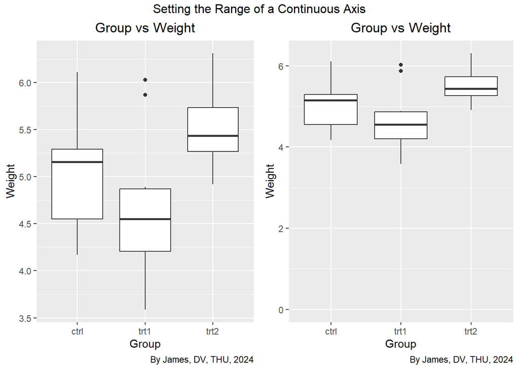

```r
p1 <- ggplot(PlantGrowth, aes(x = group, y = weight)) +
  geom_boxplot() +
  labs(title = 'Group vs Weight',
       x = 'Group',
       y = 'Weight',
       caption = 'By James, DV, THU, 2024') +
  theme(plot.title = element_text(hjust = 0.5))

p2 <- ggplot(PlantGrowth, aes(x = group, y = weight)) +
  geom_boxplot() +
  ylim(0, max(PlantGrowth$weight)) +
  labs(title = 'Group vs Weight',
       x = 'Group',
       y = 'Weight',
       caption = 'By James, DV, THU, 2024') +
  theme(plot.title = element_text(hjust = 0.5))

# Add title
grid.arrange(p1, p2, ncol = 2,
             top = 'Setting the Range of a Continuous Axis')
```

## 5. Reversing a Continuous Axis

- `scale_y_reverse()` reverses the direction of the y-axis on a plot. So, what was previously the highest value on the y-axis becomes the lowest, and vice-versa.

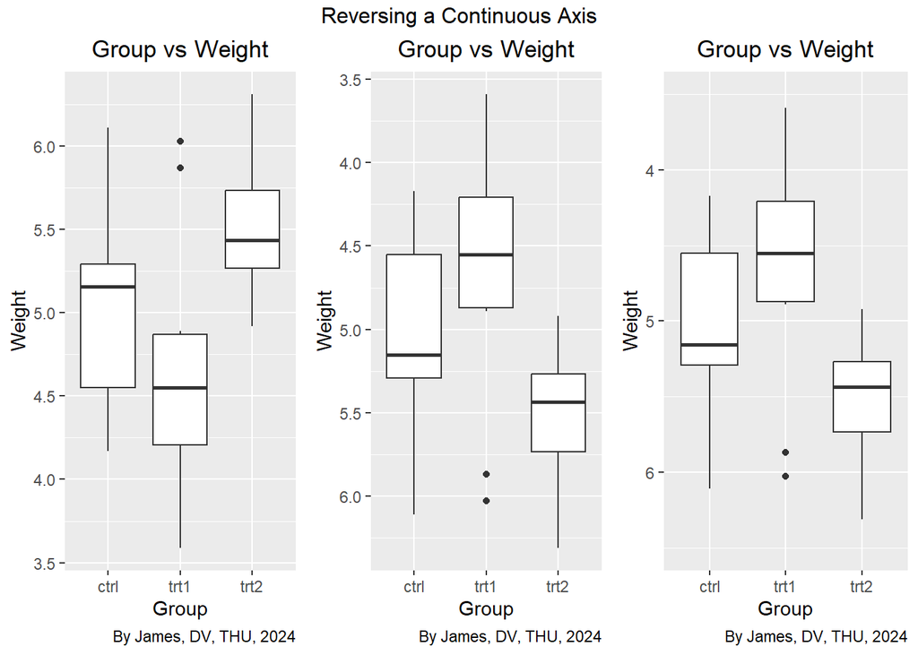

```r
p1 <- ggplot(PlantGrowth, aes(x = group, y = weight)) +
  geom_boxplot() +
  labs(title = 'Group vs Weight',
       x = 'Group',
       y = 'Weight',
       caption = 'By James, DV, THU, 2024') +
  theme(plot.title = element_text(hjust = 0.5))

p2 <- ggplot(PlantGrowth, aes(x = group, y = weight)) +
  geom_boxplot() +
  scale_y_reverse() +
  labs(title = 'Group vs Weight',
       x = 'Group',
       y = 'Weight',
       caption = 'By James, DV, THU, 2024') +
  theme(plot.title = element_text(hjust = 0.5))

p3 <- ggplot(PlantGrowth, aes(x = group, y = weight)) +
  geom_boxplot() +
  scale_y_reverse() +
  ylim(6.5, 3.5) +
  labs(title = 'Group vs Weight',
       x = 'Group',
       y = 'Weight',
       caption = 'By James, DV, THU, 2024') +
  theme(plot.title = element_text(hjust = 0.5))
# Add title
grid.arrange(p1, p2, p3, ncol = 3,
             top = 'Reversing a Continuous Axis')
```

## 6. Practice: Multiple charts from Iris

- `grid.arrange()` function from the gridExtra package in R to arrange four plots (named plot1, plot2, plot3, and plot4) into a single figure.

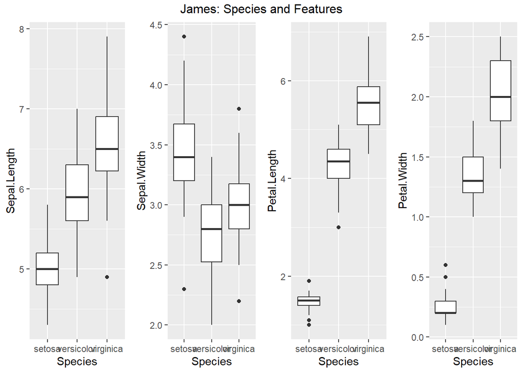

```r
plot1<-ggplot(iris, aes(x = Species, y = Sepal.Length)) +
  geom_boxplot()
plot2<-ggplot(iris, aes(x = Species, y = Sepal.Width)) +
  geom_boxplot()
plot3<-ggplot(iris, aes(x = Species, y = Petal.Length)) +
  geom_boxplot()
plot4<-ggplot(iris, aes(x = Species, y = Petal.Width)) +
  geom_boxplot()

grid.arrange(plot1, plot2, plot3, plot4, ncol=4,
             top = 'James: Species and Features')
```

## 7. Setting the Scaling Ratio of the X- and Y-Axes

- `coord_fixed()` is a function that fixes the aspect ratio of the plot. This means that the units on the x-axis and y-axis will be of equal length.

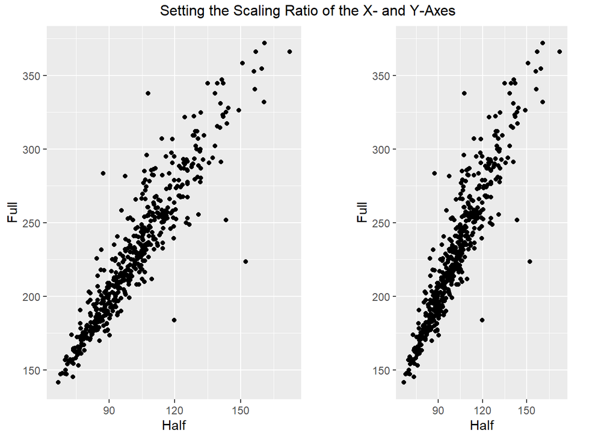

```r
library(gcookbook)

plot1 <- ggplot(marathon, aes(x=Half,y=Full)) +
  geom_point()

plot2 <- ggplot(marathon, aes(x=Half,y=Full)) +
  geom_point() +
  coord_fixed()

grid.arrange(plot1, plot2, ncol=2,
             top = 'Setting the Scaling Ratio of the X- and Y-Axes')
```

## 8. Setting the Positions of Tick Marks

- `scale_y_continuous()` is a function used to control the y-axis of a plot when the y-axis variable is continuous (meaning it can take on any value within a range, like temperature, weight, or time).

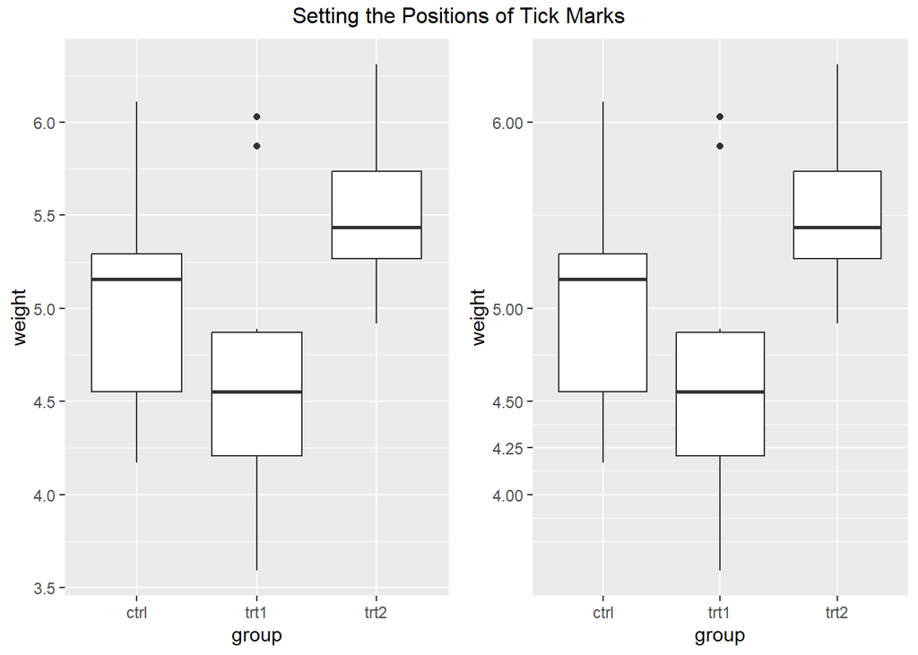

```r
p1 <- ggplot(PlantGrowth, aes(x = group, y = weight)) +
  geom_boxplot()

p2 <- ggplot(PlantGrowth, aes(x = group, y = weight)) +
  geom_boxplot() +
  scale_y_continuous(breaks = c(4, 4.25, 4.5, 5, 6, 8))

# Add title
grid.arrange(p1, p2, ncol = 2,
             top = 'Setting the Positions of Tick Marks')
```

## 9. Removing Tick Marks and Labels

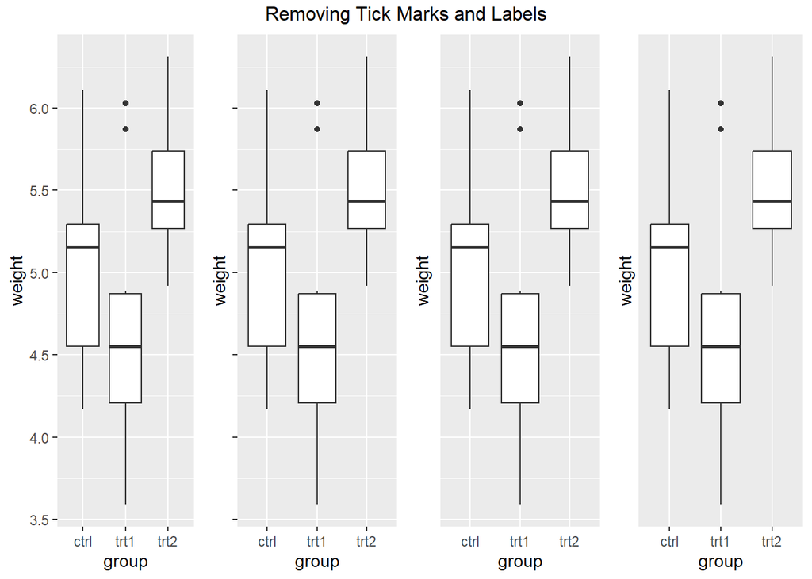

```r
p1 <- ggplot(PlantGrowth, aes(x = group, y = weight)) +
  geom_boxplot()

p2 <- ggplot(PlantGrowth, aes(x = group, y = weight)) +
  geom_boxplot() +
  theme(axis.text.y = element_blank())

p3 <- ggplot(PlantGrowth, aes(x = group, y = weight)) +
  geom_boxplot() +
  theme(axis.ticks = element_blank(), axis.text.y = element_blank())

p4 <- ggplot(PlantGrowth, aes(x = group, y = weight)) +
  geom_boxplot() +
  scale_y_continuous(breaks = NULL)

grid.arrange(p1, p2, p3, p4, ncol = 4,
             top = 'Removing Tick Marks and Labels')
```

## 10. Changing the Text of Tick Labels

- `breaks`: Specifying the locations of the tick marks and labels on the y-axis (breaks = seq(min, max, by = interval)). This gives you more control over the spacing and readability of the axis labels.
- `labels`: Customizing the text of the axis labels (labels = function(x) …). This allows for formatting, unit specification, or abbreviation of the labels.

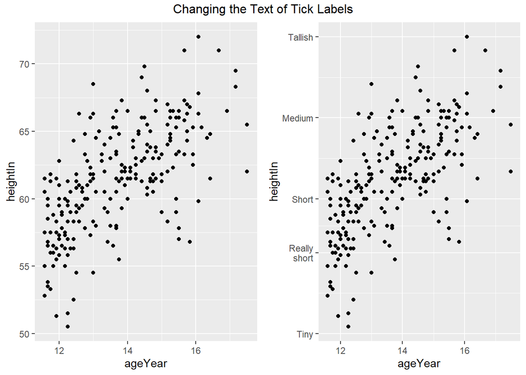

```r
library(gcookbook)

p1 <- ggplot(heightweight, aes(x = ageYear, y = heightIn)) +
  geom_point()

p2 <- ggplot(heightweight, aes(x = ageYear, y = heightIn)) +
  geom_point() +
  scale_y_continuous(
    breaks = c(50, 56, 60, 66, 72),
    labels = c("Tiny", "Really\nshort", "Short", "Medium", "Tallish")
  )

# Add title
grid.arrange(p1, p2, ncol = 2,
             top = 'Changing the Text of Tick Labels')
```

## 11. Lower ‘Tallish’ to include 6 people

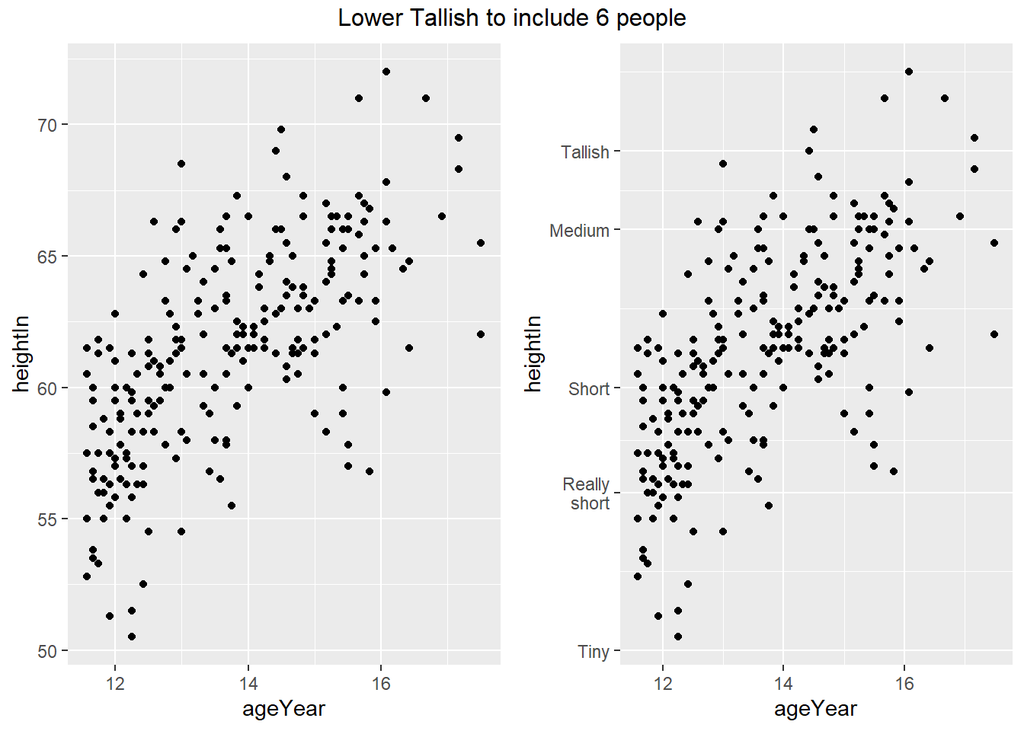

```r
p1 <- ggplot(heightweight, aes(x = ageYear, y = heightIn)) +
  geom_point()

p2 <- ggplot(heightweight, aes(x = ageYear, y = heightIn)) +
  geom_point() +
  scale_y_continuous(
    breaks = c(50, 56, 60, 66, 69),
    labels = c("Tiny", "Really\nshort", "Short", "Medium", "Tallish")
  )

# Add title
grid.arrange(p1, p2, ncol = 2,
             top = 'Lower Tallish to include 6 people')
```

## 12. Changing the Appearance of Tick Labels

- `axis.text.x = element_text(...)`: This part specifically targets the text elements of the x-axis. element_text is a function that controls the formatting of text within the plot.
- `angle = 30`: This rotates the x-axis labels by 30 degrees. This is often useful when labels are long and overlapping.

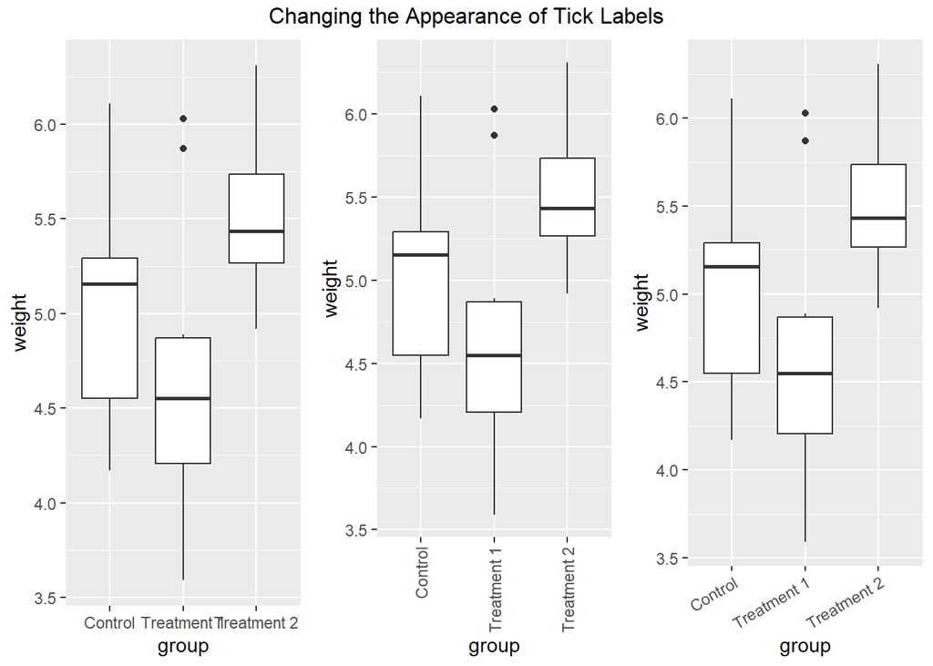

```r
pg_plot <- ggplot(PlantGrowth, aes(x = group, y = weight)) +
  geom_boxplot() +
  scale_x_discrete(
    breaks = c("ctrl", "trt1", "trt2"),
    labels = c("Control", "Treatment 1", "Treatment 2")
  )
p1 <- pg_plot
p2 <- pg_plot +
  theme(axis.text.x = element_text(angle = 90, hjust = 1, vjust = .5))
p3 <- pg_plot +
  theme(axis.text.x = element_text(angle = 30, hjust = 1, vjust = 1))

grid.arrange(p1, p2, p3, ncol = 3,
             top = 'Changing the Appearance of Tick Labels')
```

## 13. Changing the Text of Axis Labels

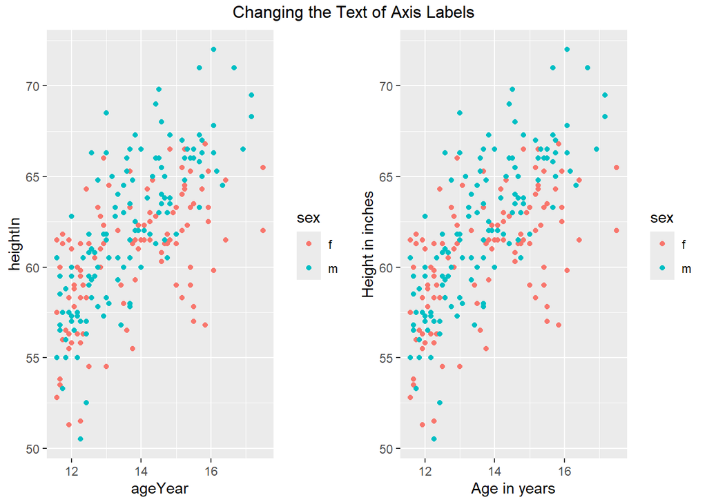

```r
hw_plot <- ggplot(heightweight, aes(x = ageYear, y = heightIn, colour = sex)) +
  geom_point()

p1 <- hw_plot
p2 <- hw_plot +
  xlab('Age in years') +
  ylab('Height in inches')

grid.arrange(p1, p2, ncol = 2,
             top = 'Changing the Text of Axis Labels')
```

## 14. Removing Axis Labels

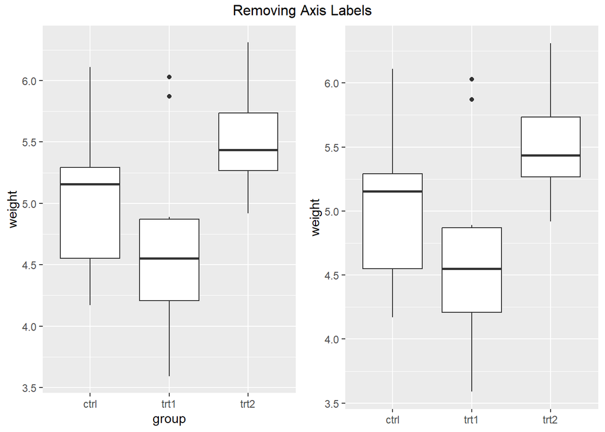

```r
p1 <- ggplot(PlantGrowth, aes(x = group, y = weight)) +
  geom_boxplot()

p2 <- p1  +
  xlab(NULL)

grid.arrange(p1, p2, ncol = 2,
             top = 'Removing Axis Labels')
```

## 15. Changing the Appearance of Axis Labels

- `axis.title.x = element_text(...)`: This specifies that we’re modifying the x-axis title. element_text is used to set text properties.

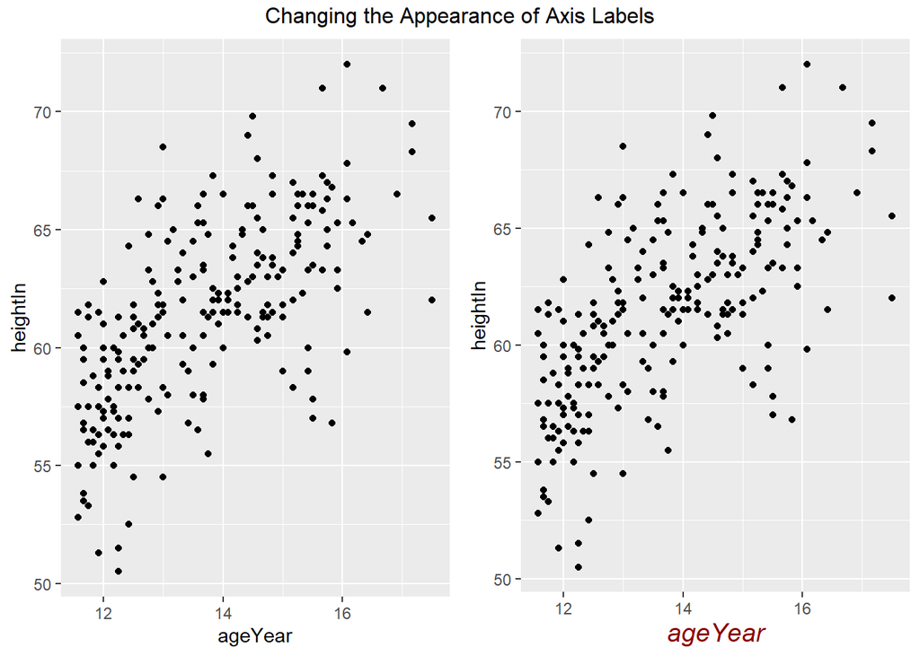

```r
p1 <- ggplot(heightweight, aes(x = ageYear, y = heightIn)) +
  geom_point()
p2 <- p1 +
  theme(axis.title.x = element_text(face = "italic", colour = "darkred",
                                    size = 14))
grid.arrange(p1, p2, ncol = 2,
             top = 'Changing the Appearance of Axis Labels')
```

## 16. Showing Lines Along the Axes

- `axis.line = element_line(colour = "black")`: This is an argument within the theme() function. It specifically targets the axis lines.

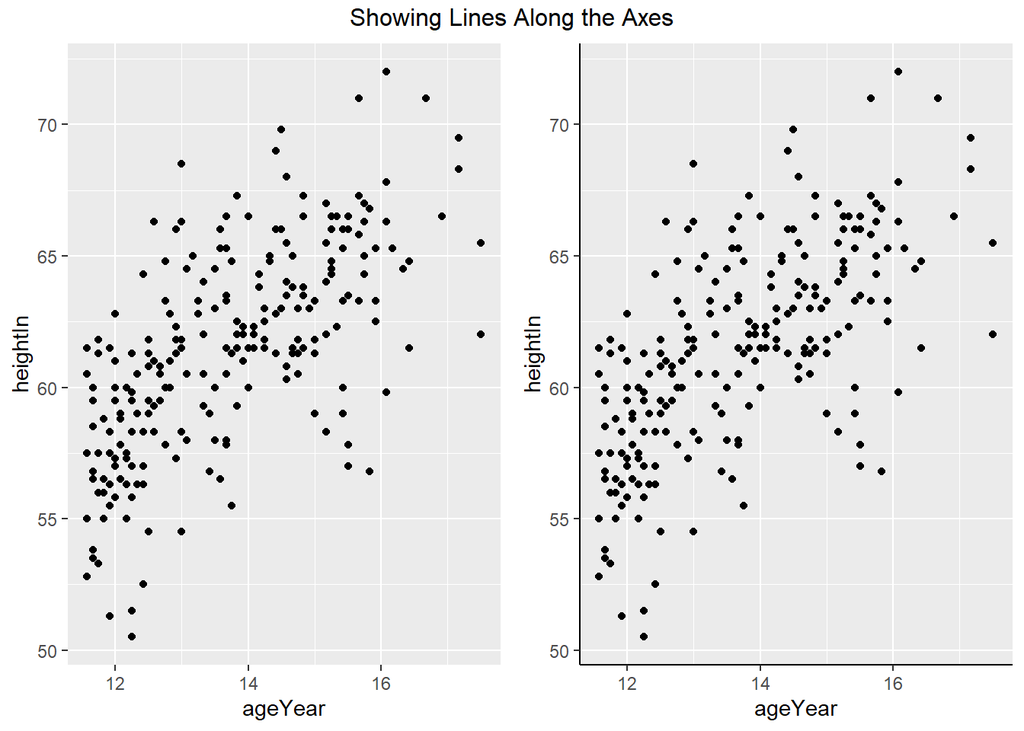

```r
p1 <- ggplot(heightweight, aes(x = ageYear, y = heightIn)) +
  geom_point()

p2 <- p1 +
  theme(axis.line = element_line(colour = "black"))

grid.arrange(p1, p2, ncol = 2,
             top = 'Showing Lines Along the Axes')
```

## 17. Using a Logarithmic Axis

- `scale_x_log10()`: It specifically applies a base-10 logarithmic transformation to the x-axis of a ggplot2 plot.

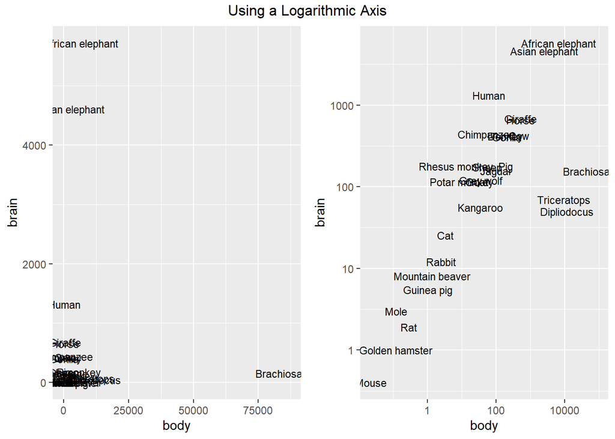

```r
library(MASS)
p1 <- ggplot(Animals, aes(x = body, y = brain, label = rownames(Animals))) +
  geom_text(size = 3)
p2 <- p1 +
  scale_x_log10() +
  scale_y_log10()
grid.arrange(p1, p2, ncol = 2,
             top = 'Using a Logarithmic Axis')
```

## 18. Making a Circular Plot

- `coord_polar()`: It transforms a Cartesian coordinate system (the usual x-y plane) into a polar coordinate system. In a polar coordinate system, points are defined by their distance from the origin (radius) and their angle from a reference direction (usually the positive x-axis, measured in radians or degrees).

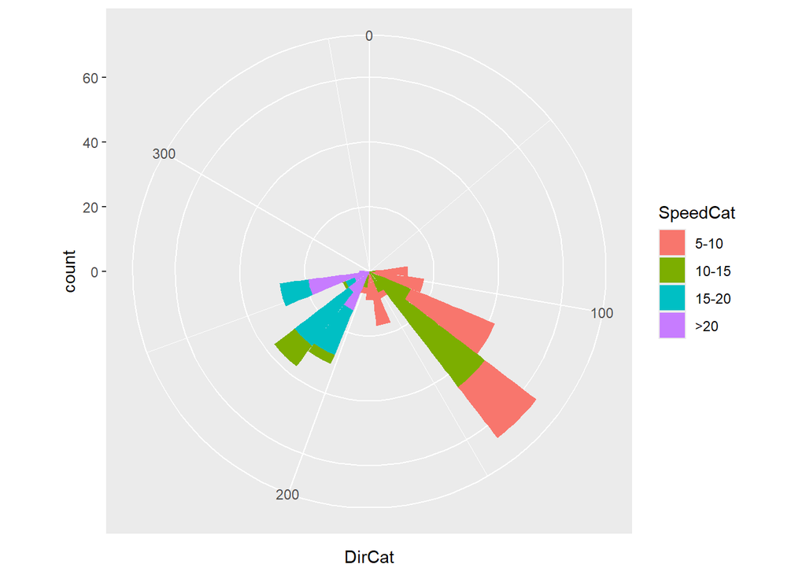

```r
ggplot(wind, aes(x = DirCat, fill = SpeedCat)) +
  geom_histogram(binwidth = 15, boundary = -7.5) +
  coord_polar() +
  scale_x_continuous(limits = c(0,360))
```

## 19. Rotate the labels on x axis

- `element_text(angle = 30, hjust = 1)` modifies the properties of the x-axis label text.
- `angle = 30` rotates the labels by 30 degrees. This is often useful when labels are long and might otherwise overlap.
- `hjust = 1` sets the horizontal justification of the text to the right. This aligns the rotated labels neatly. A value of 0 would align them to the left, and 0.5 would center them.

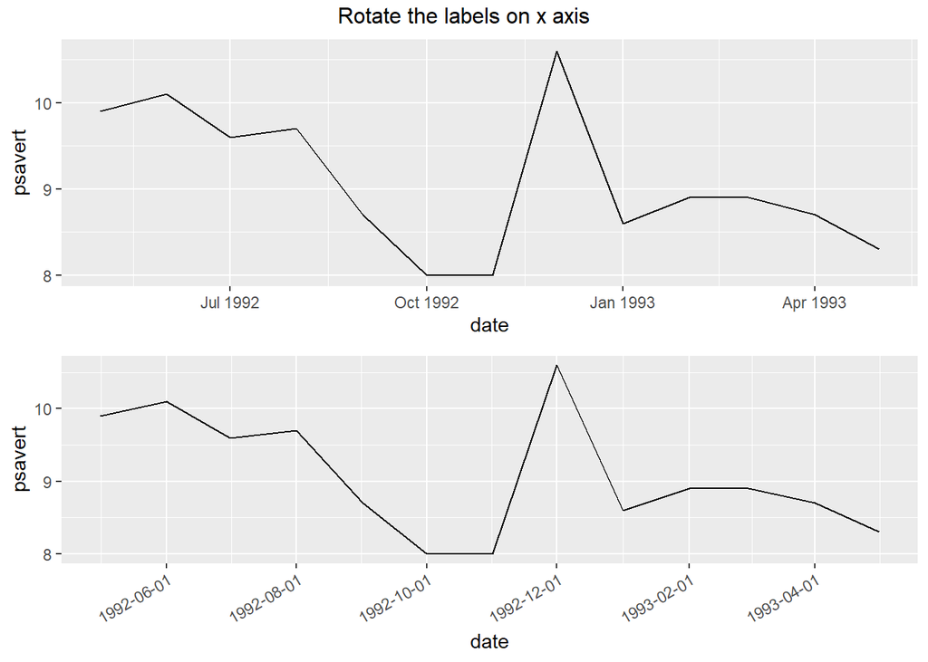

```r
library(dplyr)
# Take a subset of economics
econ_mod <- economics %>%
  filter(date >= as.Date("1992-05-01") & date <  as.Date("1993-06-01"))

# Create the base plot, which does not specify the breaks
p1 <- ggplot(econ_mod, aes(x = date, y = psavert)) +
  geom_line()

# Specify breaks as a Date vector
datebreaks <- seq(as.Date("1992-06-01"), as.Date("1993-06-01"), by = "2 month")

# Use breaks, and rotate text labels
p2 <- p1 +
  scale_x_date(breaks = datebreaks) +
  theme(axis.text.x = element_text(angle = 30, hjust = 1))

grid.arrange(p1, p2, nrow = 2,
             top = 'Rotate the labels on x axis')
```

## 20. Using Relative Times on an Axis

- `scale_x_continuous()`: It’s used to control the x-axis when creating a plot. Specifically, it’s used to modify the continuous x-axis.
- `breaks`: Defining where the tick marks appear on the x-axis (breaks = seq(min, max, by = interval)).
- `labels`: Changing the text displayed at each tick mark (labels = …)

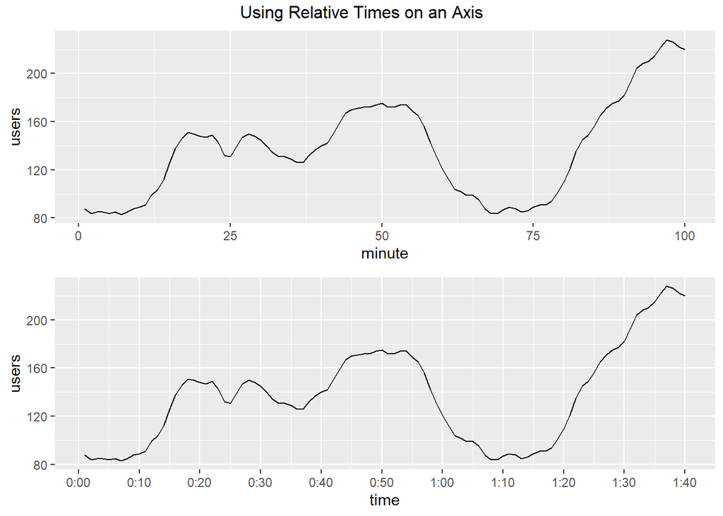

```r
# Convert WWWusage time-series object to data frame
www <- data.frame(
  minute = as.numeric(time(WWWusage)),
  users  = as.numeric(WWWusage)
)

# Define a formatter function - converts time in minutes to a string
timeHM_formatter <- function(x) {
  h <- floor(x/60)
  m <- floor(x %% 60)
  lab <- sprintf("%d:%02d", h, m) # Format the strings as HH:MM
  return(lab)
}
# Default x axis
p1 <- ggplot(www, aes(x = minute, y = users)) +
  geom_line()

# With formatted times
p2 <- ggplot(www, aes(x = minute, y = users)) +
  geom_line() +
  scale_x_continuous(
    name = "time",
    breaks = seq(0, 100, by = 10),
    labels = timeHM_formatter
  )
grid.arrange(p1, p2, nrow = 2,
             top = 'Using Relative Times on an Axis')
```